# Sabrina Zhong’s Lab 6

## Setting Up

```r
library(data.table)
library(dplyr)
library(ggplot2)
library(tidytext)

download.file(
  "https://raw.githubusercontent.com/USCbiostats/data-science-data/master/00_mtsamples/mtsamples.csv",
  destfile = "mtsamples.csv",
  method   = "libcurl",
  timeout  = 60
)

mtsamples <- data.table::fread("mtsamples.csv")

#changing column names
colnames(mtsamples) <- c("case_number", "description", "medical_specialty", "sample_name", "transcription", "keywords")

mtsamples <- mtsamples[-c(1),]
```

## Question 1

```r
medical_categories <- mtsamples %>% count(medical_specialty)
dim(medical_categories)
```

```
[1] 40  2
```

```r
medical_categories[order(n, decreasing = T),]
```

```
                medical_specialty    n
 1:                       Surgery 1103
 2:    Consult - History and Phy.  516
 3:    Cardiovascular / Pulmonary  372
 4:                    Orthopedic  355
 5:                     Radiology  273
 6:              General Medicine  259
 7:              Gastroenterology  230
 8:                     Neurology  223
 9: SOAP / Chart / Progress Notes  166
10:       Obstetrics / Gynecology  160
11:                       Urology  158
12:             Discharge Summary  108
13:          ENT - Otolaryngology   98
14:                  Neurosurgery   94
```

[output cut: 27 more lines]

There are 40 different categories of specialties in the data set. These categories are related in that they are different medical specialties in the medical field. Some medical specialties focuses on the same biological system or organ in the body. None of the categories are overlapping. The most cases in the data set come from surgery followed by consult and cardiovascular/pulmonary.

## Question 2

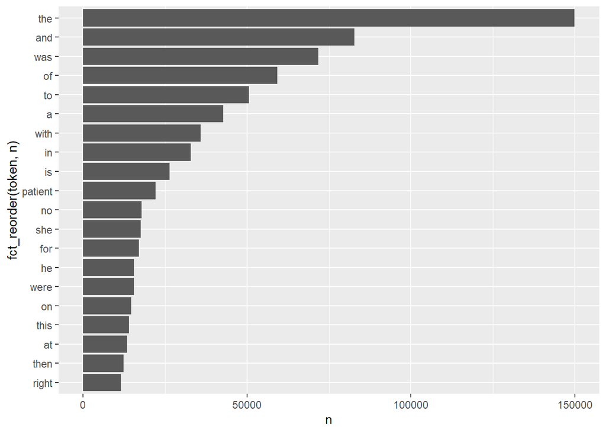

```r
mtsamples2 <- mtsamples

library(forcats)

mtsamples2 %>%
  unnest_tokens(token, transcription) %>%
  count(token) %>%
  top_n(20, n) %>%
  ggplot(aes(n, fct_reorder(token, n))) +
  geom_col()
```

The top words include “the”, “and”, “patient”, “she”, “he”, and other words. It is expected that these words are in the top 20 most frequent words in the transcription. Most of these words are preposition words that describes relationships between words which is required in most sentences. “Patient” is also expected to be seen a lot in the transcriptions because the physicians should be referring to the patient in their transcriptions.

## Question 3

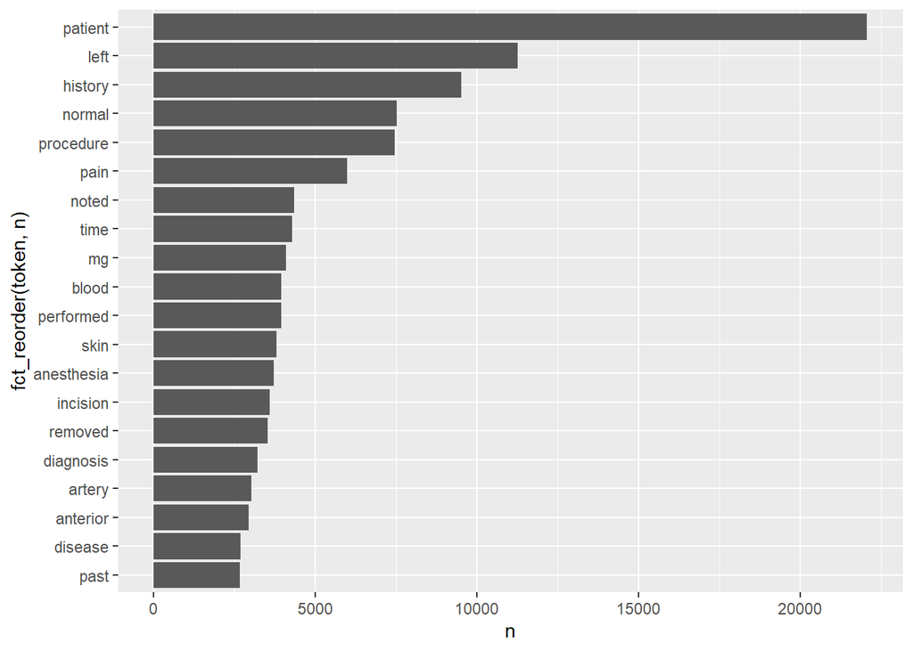

```r
mtsamples2 %>%
  unnest_tokens(token, transcription) %>%
  anti_join(stop_words, by = c("token" = "word")) %>%
  filter(!grepl("^\\d+$", token)) %>%
  count(token, sort = TRUE) %>%
  top_n(20, n) %>%
  ggplot(aes(n, fct_reorder(token, n))) +
  geom_col()
```

Now that stop words are removed, we can see that the top words include “patient”, “left”, “procedure”, “pain”, and others. A lot of the words in the top 20 are related to surgical procedures such as “anesthesia” and “incision”. This is expected because the most entries are from the surgery specialty. These words give us context about the procedure being done on the patient.

## Question 4

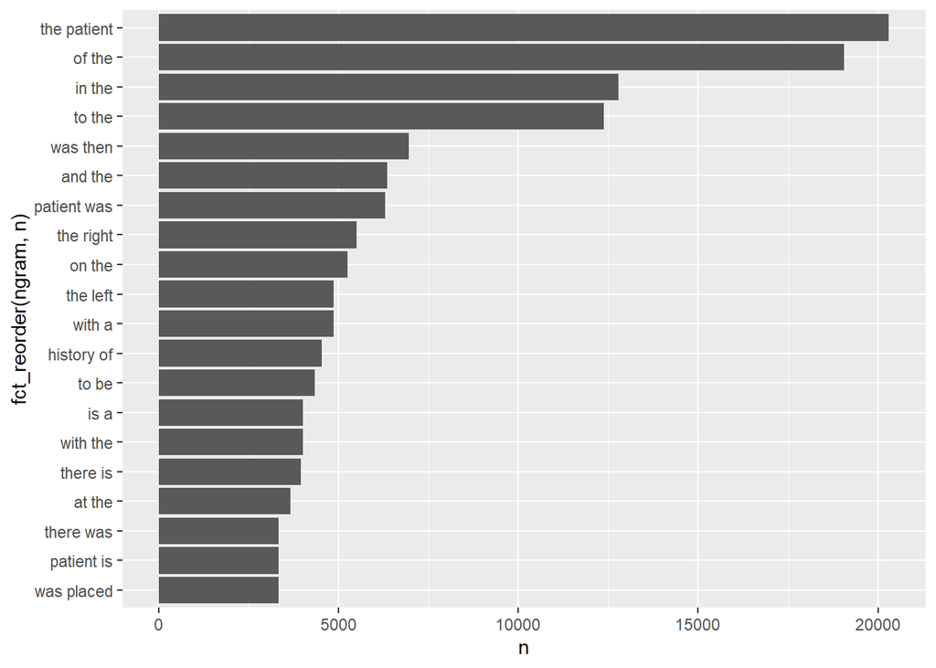

```r
mtsamples2 %>%
  unnest_ngrams(ngram, transcription, n = 2) %>%
  count(ngram, sort = TRUE) %>%
  top_n(20, n) %>%
  ggplot(aes(n, fct_reorder(ngram, n))) +
  geom_col()
```

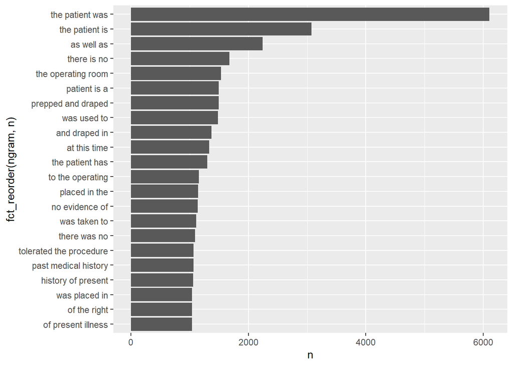

```r
mtsamples2 %>%
  unnest_ngrams(ngram, transcription, n = 3) %>%
  count(ngram, sort = TRUE) %>%
  top_n(20, n) %>%
  ggplot(aes(n, fct_reorder(ngram, n))) +
  geom_col()
```

In both ngrams, the top most frequent phrase includes “the patient”. A lot of the phrases also describe the location of something. The tri-grams give more context which makes sense since it includes an addition word in the phrase.

## Question 5

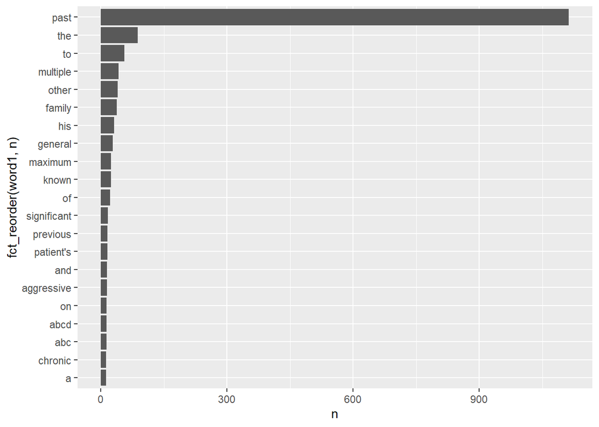

```r
library(tidyr)

#words before
mtsamples2 %>%
  unnest_ngrams(ngram, transcription, n = 2) %>%
  separate(ngram, into = c("word1", "word2"), sep = " ") %>%
  select(word1, word2) %>%
  filter(word2 == "medical") %>%
  count(word1, sort = TRUE) %>%
  top_n(20, n) %>%
  ggplot(aes(n, fct_reorder(word1, n))) +
  geom_col()
```

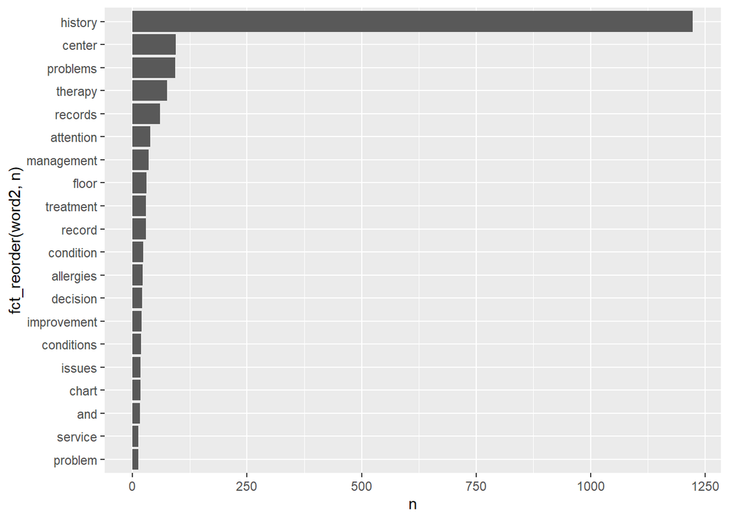

```r
#words after
mtsamples2 %>%
  unnest_ngrams(ngram, transcription, n = 2) %>%
  separate(ngram, into = c("word1", "word2"), sep = " ") %>%
  select(word1, word2) %>%
  filter(word1 == "medical") %>%
  count(word2, sort = TRUE) %>%
  top_n(20, n) %>%
  ggplot(aes(n, fct_reorder(word2, n))) +
  geom_col()
```

The word I chose was “medical”. The most frequent words to come before “medical” are “past”, “the”, and “to”. The most frequent words to come after “medical” are “history”, “center”, and “problems”.

## Question 6

```r
top5 <- mtsamples2 %>%
  group_by(medical_specialty) %>%
  unnest_tokens(token, transcription) %>%
  anti_join(stop_words, by = c("token" = "word")) %>%
  filter(!grepl("^\\d+$", token)) %>%
  count(token, sort = TRUE) %>%
  top_n(5, n)

top5 <- top5 %>% arrange(medical_specialty)

top5
```

```
# A tibble: 210 × 3
# Groups:   medical_specialty [40]
   medical_specialty    token         n
   <chr>                <chr>     <int>
 1 Allergy / Immunology history      38
 2 Allergy / Immunology noted        23
 3 Allergy / Immunology patient      22
 4 Allergy / Immunology allergies    21
 5 Allergy / Immunology nasal        13
 6 Allergy / Immunology past         13
 7 Autopsy              left         83
 8 Autopsy              inch         59
 9 Autopsy              neck         55
10 Autopsy              anterior     47
# ℹ 200 more rows
```

The top 5 most used words in the allergy/immunology are “history”, “noted”, “patient”, “allergies”, “nasal”, and “past”. “Nasal” and “past” are tied for 5th most used. For dentistry, it’s “patient”, “tooth”, “teeth”, “left”, and “procedure”. The top 5 most frequent words of other specialties can be seen from the “top5” table.

## Question 7

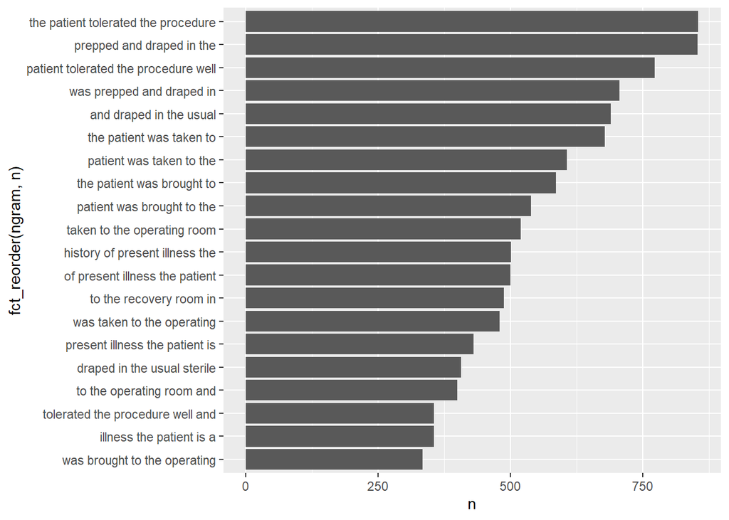

```r
mtsamples2 %>%
  unnest_ngrams(ngram, transcription, n = 5) %>%
  count(ngram, sort = TRUE) %>%
  top_n(20, n) %>%
  ggplot(aes(n, fct_reorder(ngram, n))) +
  geom_col()
```

Using 5grams, it is interesting that a lot of the transcripts mention how the patient reacted to the procedure done.